# Logistic Regression - Predicting Diabetes Diagnosis

4/26/2020

Lealena Befikadu

## Data Cleaning/Preparation

Before I analyzed the “diabetes.csv” dataset, I had to do some cleaning. First, I called the libraries needed for my analyzation. I then proceeded to set my directory and import the dataset into the variable of my choice (“diabete”). After, I created a variable called “height.si” and converted the height variable to SI units by multiplying the height variable by 0.0254 into that new variable. I also created a variable called “weight.si” and converted the weight variable to SI units by multiplying the weight variable by 0.453592 into that new variable. I then took those two variables and created a “BMI” variable and put the formula: weight.si/height.si^2, into that variable. Next, I created a categorical BMI variable named “bmi_categorised” and set conditions to the BMI variable. Those conditions were: bmi < 18.5 was set to equal “underweight”, bmi >= 18.5 & bmi <= 25 was set to equal “normal”, bmi > 25 & bmi <= 30 was set to equal “overweight”, bmi > 30 was set to equal “obese”, and all other values were set to NA. Lastly, I recoded the insurance variable and the smoking variable to reflect their value labels.

```r
# insert import & data cleaning code here
#set libraries
library(dplyr)
library(ggplot2)
library(tidyverse)
#set directory
setwd("/Users/lealenabefikadu/Downloads")
#opened file and set it equal to a variable
diabete <- read.csv("diabetes.csv", header = TRUE)
#created new varibale for height with coversion
height.si <- diabete$height*0.0254
#created new varibale for weight with coversion
weight.si <- diabete$weight*0.453592
#created BMI with calculation
BMI <- weight.si/height.si^2
#recode BMI
bmi_categorised<- ifelse(BMI < 18.5,"underweight",
                         ifelse(BMI >= 18.5 & BMI <= 25,"normal",
                                ifelse(BMI > 25 & BMI <= 30,"overweight",
                                       ifelse(BMI > 30,"obese",
                                              NA))))

#recode insurance
diabete$insurance<- ifelse(diabete$insurance==0, "none",
                            ifelse(diabete$insurance==1,"government",
                                   ifelse(diabete$insurance==2, "private", NA)))


#recode smoking
diabete$smoking<- ifelse(diabete$smoking==1, "current",
                          ifelse(diabete$smoking==2, "never",
                                 ifelse(diabete$smoking==3, "ex-smoker", NA)))
```

## Exploratory Data Analysis

While analyzing the “diabetes.csv” dataset, I found there to be 403 observations. The percentage of individuals who are obese in the dataset is 38.3%. The percentage of individuals who are female in the dataset is 58.1%. The percentage of individuals who have diabetes in the dataset is 15.4%. The average age for individuals in the dataset is 46.9 (47). The average BMI for individuals in the dataset is 28.8.

```r
# insert exploratory data analysis code here
#num of observations
nrow(diabete)
```

```
## [1] 403
```

```r
#percentage of observations for bmi
round(prop.table(table(bmi_categorised))*100, digit = 1)
```

```
## bmi_categorised
##      normal       obese  overweight underweight
##        28.5        38.3        31.0         2.3
```

```r
#percentage of observations for gender
round(prop.table(table(diabete$gender))*100, digit = 1)
```

```
##
## female   male
##   58.1   41.9
```

```r
#percentage of observations for diabetes
round(prop.table(table(diabete$dm))*100, digit = 1)
```

```
##
##    0    1
## 84.6 15.4
```

```r
#average age
mean(diabete$age)
```

```
## [1] 46.85112
```

```r
#average BMI
mean(BMI, na.rm=T)
```

```
## [1] 28.7874
```

## Data Visualization

**Figure 1**

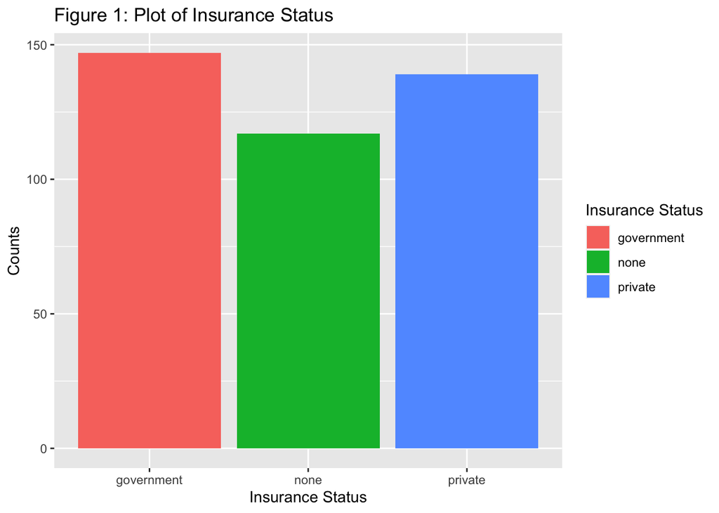

```r
# insert data visualization code here
#bar chart for labeled insurance
ggplot(data=diabete) +
  geom_bar(mapping = aes(x=insurance, fill = insurance)) +
  labs(title="Figure 1: Plot of Insurance Status",x="Insurance Status", fill= "Insurance Status",y="Counts")
```

**Figure 2**

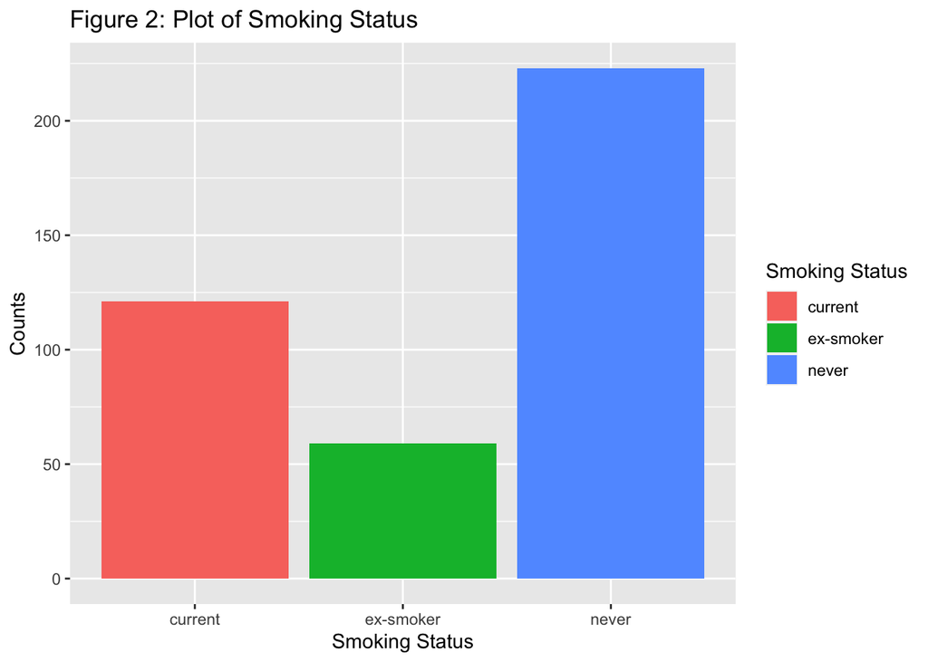

```r
# insert data visualization code here
#bar chart for smoking
ggplot(data=diabete) +
  geom_bar(mapping = aes(x=smoking, fill = smoking)) +
  labs(title="Figure 2: Plot of Smoking Status",x="Smoking Status", fill="Smoking Status",y="Counts")
```

**Figure 3**

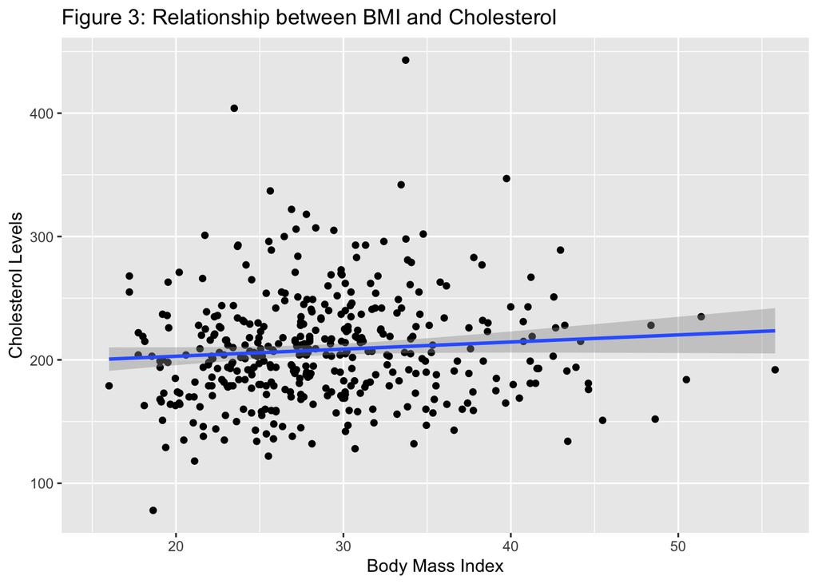

```r
# insert data visualization code here
#scatter plot for BMI and cholesterol
ggplot(diabete, aes(x = BMI, y = chol)) +
            geom_point() +
            geom_smooth(method="lm")+
  labs(title="Figure 3: Relationship between BMI and Cholesterol",x="Body Mass Index", y = "Cholesterol Levels")
```

**Figure 4**

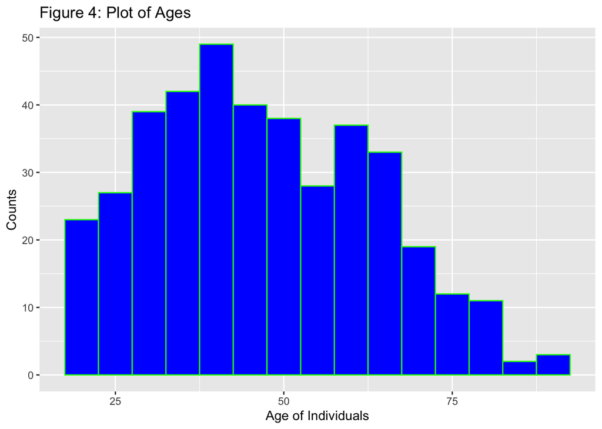

```r
# insert data visualization code here
#histogram for age
ggplot(data=diabete) + geom_histogram(mapping = aes(x=age), fill="blue", color="green", binwidth = 5) + labs(title="Figure 4: Plot of Ages",x="Age of Individuals",y="Counts")
```

## Logistic Regression Results

The results of the logistic regression showed that for a 1-year increase in age, the logs of having diabetes increases by 0.055454, holding the other independent variables constant. For a l-unit increase in body mass index, the logs of having diabetes increases by 0.073879, holding the other independent variables constant. The log odds of having diabetes between a male and a female is 0.244852, holding the other independent variables constant.

```r
# insert logistic regression code
logD <- glm(dm ~ age + BMI + gender, data = diabete, family = "binomial")
summary(logD)
```

```
##
## Call:
## glm(formula = dm ~ age + BMI + gender, family = "binomial", data = diabete)
##
## Deviance Residuals:
##     Min       1Q   Median       3Q      Max
## -1.6843  -0.5763  -0.3885  -0.2575   2.6991
##
## Coefficients:
##              Estimate Std. Error z value Pr(>|z|)
## (Intercept) -6.892669   1.027388  -6.709 1.96e-11 ***
## age          0.055454   0.009884   5.611 2.02e-08 ***
## BMI          0.073879   0.023310   3.169  0.00153 **
## gendermale   0.244852   0.322817   0.758  0.44816
## ---
## Signif. codes:  0 '***' 0.001 '**' 0.01 '*' 0.05 '.' 0.1 ' ' 1
##
## (Dispersion parameter for binomial family taken to be 1)
##
##     Null deviance: 326.02  on 383  degrees of freedom
## Residual deviance: 281.62  on 380  degrees of freedom
##   (19 observations deleted due to missingness)
## AIC: 289.62
##
## Number of Fisher Scoring iterations: 5
```